# index

## Project Introduction

This study investigates the online community migration of "TikTok Refugees"—users transitioning from the US-based platform TikTok to the China-based platform RedNote. Through a structured survey of 130 participants, this research explores cross-platform migration motivations, application usage patterns, and user privacy perceptions.

### Acknowledgements

We gratefully acknowledge the support of the 2025 Consumer Protection Research Grant from the University of Oregon School of Law. We also sincerely thank all participants who generously shared their time and experiences—this project would not have been possible without you.

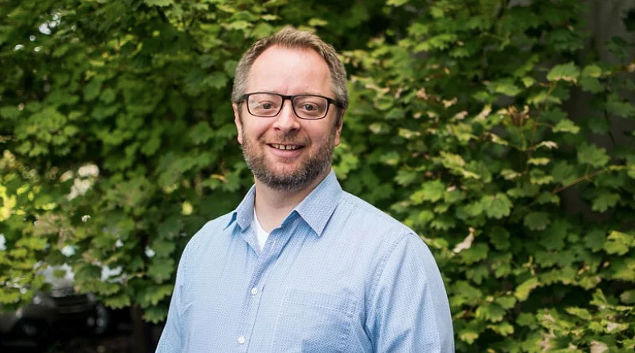

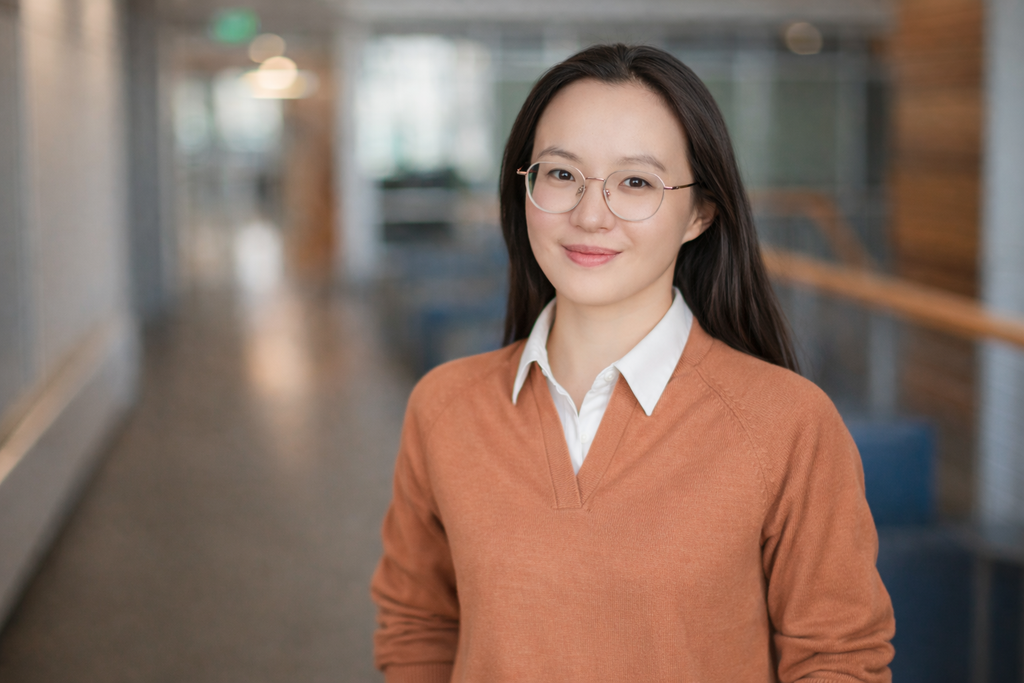

[figure not shown]

## Bryce Clayton Newell

Project Lead

Bryce Clayton Newell, PhD, JD, is The David and Nancy Petrone Faculty Fellow and Associate Professor in the School of Journalism and Communication at the University of Oregon. He is an information scientist and socio-legal scholar whose research investigates the social, legal, and ethical implications of information technologies in society.

## Yanfei Lin

Doctoral Student

Yanfei (she/her) is a PhD student in communication and media studies at the University of Oregon. Her research interests include digital media governance, platform power, privacy and data ethics, and the societal impacts of emerging technologies, using mixed and computational methods.

## Lanore Hahn

Doctoral Student

Lanore Hahn is a PhD student in the School of Journalism and Communication at the University of Oregon. Her research examines large language models through critical political economy and care ethics, focusing on how LLMs reshape communication, labor, and relational practices in healthcare systems.